# Laboratorium 12

## Szum

### PLN

```python
szum_zloty=dane.iloc[:,1].rolling(window=100).mean()-dane["zloty"]
```

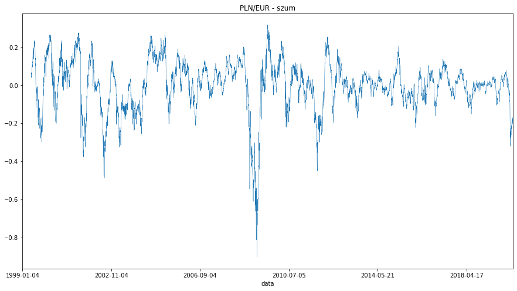

```python
plt.figure(figsize=(15,8))
szum_zloty.plot(linewidth=0.5)
plt.title("PLN/EUR - szum")
```

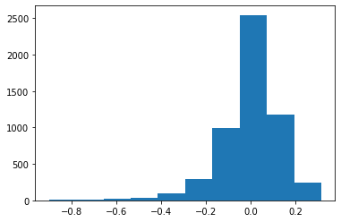

```python
plt.hist(szum_zloty[101:])
```

```python
stats.normaltest(szum_zloty[101:])
```

```
NormaltestResult(statistic=1551.296239375824, pvalue=0.0)
```

```
((array([-3.65666114, -3.4226079 , -3.29367332, ...,  3.29367332,
          3.4226079 ,  3.65666114]),
  array([-0.903202, -0.82553 , -0.813755, ...,  0.298268,  0.316435,
          0.316646])),
 (0.1272746005354922, -0.0017828787096821948, 0.9605574623966323))
```

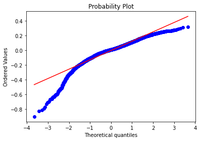

```python
stats.probplot(szum_zloty[101:],dist='norm',plot=pylab)
```

Po analizie reszt możemy stwierdzić, że złotówka. Poza czasami kryzysu gospodarczego zachowuje się jak biały szum

### CHF

```python
szum_frank=dane.iloc[:,2].rolling(window=100).mean()-dane["frank"]
```

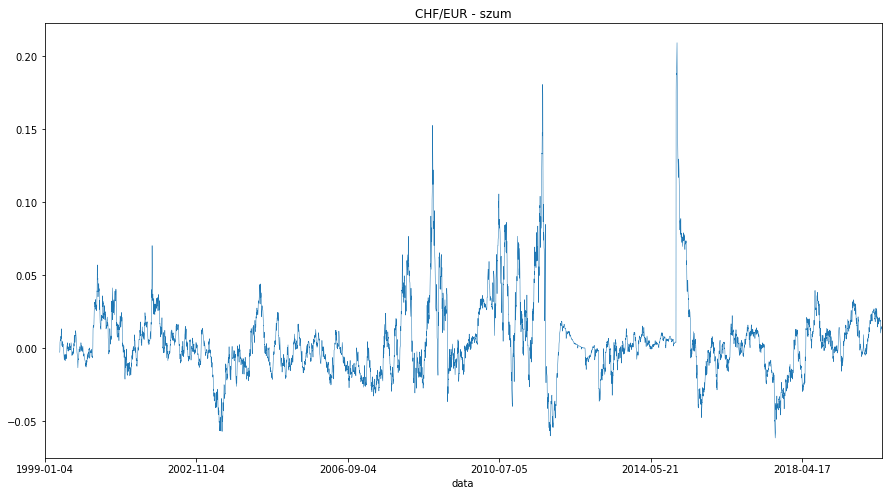

```python
plt.figure(figsize=(15,8))
szum_frank.plot(linewidth=0.5)
plt.title("CHF/EUR - szum")
```

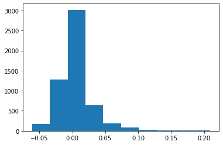

```python
plt.hist(szum_frank[101:])
```

```python
stats.normaltest(szum_frank[101:])
```

```
NormaltestResult(statistic=2419.146545118868, pvalue=0.0)
```

```
((array([-3.65666114, -3.4226079 , -3.29367332, ...,  3.29367332,
          3.4226079 ,  3.65666114]),
  array([-0.061341, -0.059907, -0.059873, ...,  0.195572,  0.198843,
          0.209287])),
 (0.023971623372642976, 0.004938039262673638, 0.9296594170653767))
```

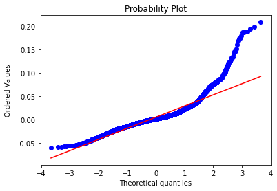

```python
stats.probplot(szum_frank[101:],dist='norm',plot=pylab)
```

Frank szwajcarski nie zachowuje się jak biały szum, jednak z wykresu kwantyl kwantyl w bezpośredni sposób widać, że znacząca liczba odchyleń jest pozytywna dla franka. Może być to jednak spowodowane pojedyńczym okresem wzrostu tej waluty.

### GBP

```python
szum_funt=dane.iloc[:,3].rolling(window=100).mean()-dane["funt"]
```

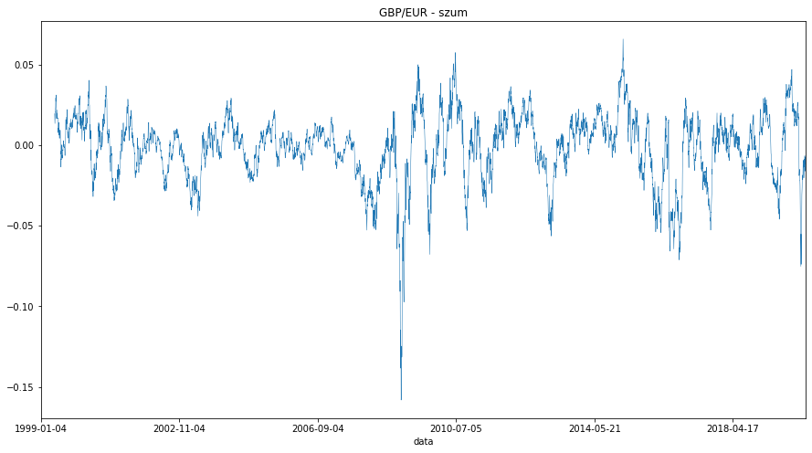

```python
plt.figure(figsize=(15,8))
szum_funt.plot(linewidth=0.5)
plt.title("GBP/EUR - szum")
```

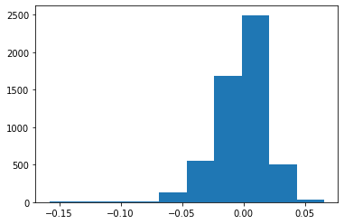

```python
plt.hist(szum_funt[101:])
```

```python
stats.normaltest(szum_funt[101:])
```

```
NormaltestResult(statistic=1350.2380660533292, pvalue=6.30273908044873e-294)
```

```
((array([-3.65666114, -3.4226079 , -3.29367332, ...,  3.29367332,
          3.4226079 ,  3.65666114]),
  array([-0.1580645, -0.15612  , -0.154151 , ...,  0.057438 ,  0.0593955,
          0.0657685])),
 (0.02034882924116143, -0.00186256976958448, 0.9714980359088808))
```

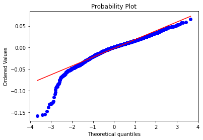

```python
stats.probplot(szum_funt[101:],dist='norm',plot=pylab)
```

Funt wygląda za to na niebezpieczną walutę, która w dobie krysyzu gospodarczego może spowodować jedynie mocne straty. Zyski jednak są bardzo przewidywalne. Z dobrze zabezpieczonym budżetem, to GBP może okazać najlepsza do inwestywania

## Szacowanie natury szeregu czasowego

### PLN

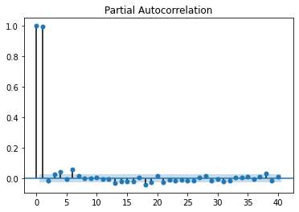

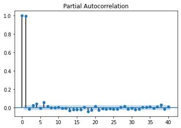

```python
sm.graphics.tsa.plot_pacf(dane['zloty'],lags=40)
```

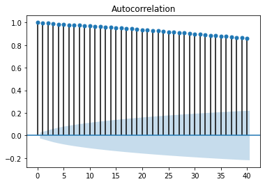

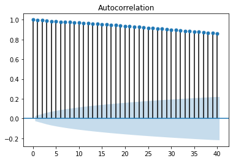

```python
sm.graphics.tsa.plot_acf(dane['zloty'],lags=40)
```

### CHF

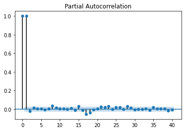

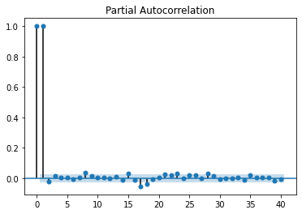

```python
sm.graphics.tsa.plot_pacf(dane['frank'],lags=40)
```

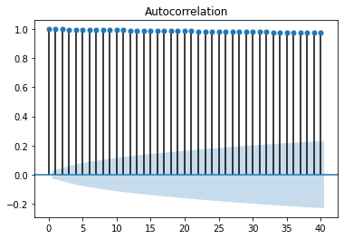

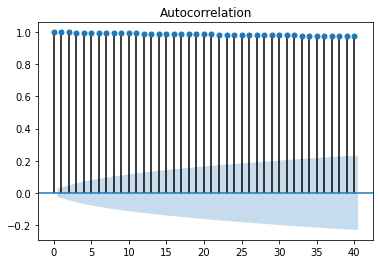

```python
sm.graphics.tsa.plot_acf(dane['frank'],lags=40)
```

### GBP

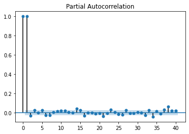

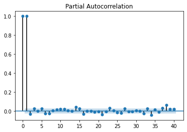

```python
sm.graphics.tsa.plot_pacf(dane['funt'],lags=40)
```

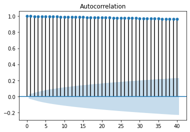

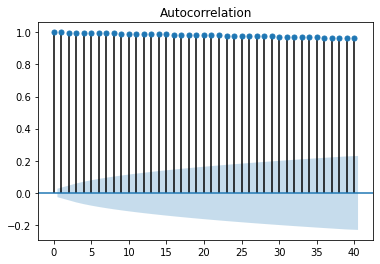

```python
sm.graphics.tsa.plot_acf(dane['funt'],lags=40)
```

# Wnioski

### PLN

Sezonowość wariancji złotówki w okresach letnich może być spowodowane licznymi wyjazdami Polskiej młodzieży na dorobek sezonowy do krajów strefy euro podczas rozwoju polskiej gospodarki. Kurs waluty mógłbyc potrzebny ludziom "na stat" oraz po powrtocie z zarobku co mogło zwiększyć zapotrzebowanie z obu stron na EURO co przyczyniło się do mniejszej warianicji w okresi letnim.

Zauważyliśmy również wpływ wstąpienia Polski do UE, światowego kryzysu i pandemii COVID-19 na kurs złotego względem innych walut. Są to okresy owocene dla spekulantów ze względu na swój przewidywalny wzrotost wariacnji. Bardzo interesujacym zdaje się okres umocnienia Polskiej waluty od 2004 roku do 2008 roku. Możliwe, że jest to spowodowane licznymi inwestycjami unii europejskiej w Polsce w tym okresie

### CHF

Frank szwajcarski okazuje się być najbardziej stabilną walutą w stosunku do euro w porównaniu do pozostałych analizowanych walut. Nie wykazuje się sezonowością i w ostatnich latach sukcesywnie zyskiwał na swojej wartości.

### GBP

Sezonowość wariancji funta w okresie noworocznym najprawdopodobniej wynika z działania londyńskiego city na ekonomie całej Wielkiej Brytanii. Panuje tam wieloletnia kultura premii rocznych które są w stanie dorównać rocznym zarobkom. Premie wypłacane są w grudniu, a wraz z nimi są powiązane ogromne rotacje pracowników oraz samego pieniądza.

W 2008 roku również widzimy najmocniejsze oddziaływanie światowego kryzysu na kurs funta. Nie powinno to być jednak dziwne, ponieważ kryzys ten miał czysto charakter finansowy a Londyn jest światową stolicą finansów.

### Dodatkowa notka

O wiele lepszym rozwiązaniem mogłoby być użycie bardziej wyrafinowanych modeli nie zakładających homoskedastyczności. Frank Szwajcarski jest najbardziej stabilną lub najbardziej utożsamoioną z Euro walutom. Nie mniej jednak naszym zadaniem była analzia danych, a nie ich predykcja.